# Beta cell type-specific network in pancreas islet tissues

Weixu Wang

2022/1/25

## Tuning the parameter through evaluating concordance with external scRNA-seq datasets

In order to more accurately identify the beta cell type-specific network, we need to tune our model parameter. To realize this goal, we integrated previous published single cell datasets sequenced both normal and T2D patients, and tune the parameter so that our inferred beta cell expression variantion among normal and T2D patients would have high concordance with the real single cell datasets. We used following concordance function to perform evaluation

```r
evaluate_concordance_pancreas <- function(predict,table,n_boot=1000,sig_threshold=1){
    ind1 = which(is.nan(predict[,2])==FALSE)
    ind2 = which(is.nan(table[,2])==FALSE)
    ind = intersect(ind1,ind2)
    predict = predict[ind,]
    table = table[ind,]
    seq <- runif(n_boot)
    ES <- abs((predict[predict[,2]<sig_threshold,1]))
    seq <- quantile(ES,seq)
    prob <- NULL
    for(i in 1:length(seq)){
        predict_filter <- predict[predict[,2]<sig_threshold&abs((predict[,1]))>seq[i],]
        predict_filter <- predict_filter[order(predict_filter[,1],decreasing=FALSE),]

        table_sub <- table[rownames(predict_filter),]
        prob <- c(prob,sum(diag(table(sign((predict_filter[,1])),sign((table_sub[,1])))))/sum(table(sign((predict_filter[,1])),sign((table_sub[,1])))))
    }

    prob
}

evaluate_concordance_pancreas_top500 <- function(predict,table,n_boot=1000,sig_threshold=1){
    ind1 = which(is.nan(predict[,2])==FALSE)
    ind2 = which(is.nan(table[,2])==FALSE)
    ind = intersect(ind1,ind2)
    predict = predict[ind,]
    table = table[ind,]
    seq <- runif(n_boot)
    predict[,2][order(predict[,2],decreasing=FALSE)[501]] -> sig_threshold
    ES <- abs((predict[predict[,2]<sig_threshold,1]))
    seq <- quantile(ES,seq)
    prob <- NULL
    for(i in 1:length(seq)){
        predict_filter <- predict[predict[,2]<sig_threshold&abs((predict[,1]))>seq[i],]
        predict_filter <- predict_filter[order(predict_filter[,1],decreasing=FALSE),]

        table_sub <- table[rownames(predict_filter),]
        prob <- c(prob,sum(diag(table(sign((predict_filter[,1])),sign((table_sub[,1])))))/sum(table(sign((predict_filter[,1])),sign((table_sub[,1])))))
    }

    prob
}
```

First, we tune our model according to our parameter analyses (see Supplementary Note). As our reference is from total different batch and sequencing platform compare with bulk RNA-seq datasets, the idea parameter of alpha would be 0.9, and we also increase the parameter beta, so that the model could converge fastly.

```r
egm_model2 <- cell_deconvolve(X=as.matrix(log2((tmp_pancreas$bulk)+1)),
                                     theta=Fra_pancreas$theta,
                                     R=as.matrix(log2(tmp_pancreas$cell_type1+1)),
                                     epsilon = 0.001,
                                     alpha=0.9,
                                     beta=0.5,tao_k=0.01,max.iter=1000,verbose=FALSE,Normalize=FALSE,pre.process="log")
```

```
## Done!
## Converge in 15 steps
```

We calculated the DEGs for both of ENIGMA models through OLS model (egm_model1(raw model), egm_model2(new model))

```r
Exp <- egm_model1$X_k[,sample,"beta"]
DEG <- NULL
for(j in 1:nrow(Exp)){
if(var(Exp[j,])>0){
pvalue <- summary(lm((Exp[j,][Fra_pancreas$theta[sample,3]!=0])~metadata[sample,][Fra_pancreas$theta[sample,3]!=0,]$HbA1c))$coefficients[2,4]
FC <- summary(lm((Exp[j,][Fra_pancreas$theta[sample,3]!=0])~metadata[sample,][Fra_pancreas$theta[sample,3]!=0,]$HbA1c))$coefficients[2,1]
line <- c(FC,pvalue)
DEG <- rbind(DEG,line)
}else{
line <- c(NA,NA)
DEG <- rbind(DEG,line)
}
}
DEG <- as.data.frame(DEG)
colnames(DEG) <- c("FC","pvalue")
rownames(DEG) <- rownames(Exp)
DEG$p.adj <- p.adjust(DEG$pvalue,method="BH")
DEG_list_pancreas_hba1c_model1 <- DEG


Exp <- egm_model2$X_k[,sample,"beta"]
DEG <- NULL
for(j in 1:nrow(Exp)){
if(var(Exp[j,])>0){
pvalue <- summary(lm((Exp[j,][Fra_pancreas$theta[sample,3]!=0])~metadata[sample,][Fra_pancreas$theta[sample,3]!=0,]$HbA1c))$coefficients[2,4]
FC <- summary(lm((Exp[j,][Fra_pancreas$theta[sample,3]!=0])~metadata[sample,][Fra_pancreas$theta[sample,3]!=0,]$HbA1c))$coefficients[2,1]
line <- c(FC,pvalue)
DEG <- rbind(DEG,line)
}else{
line <- c(NA,NA)
DEG <- rbind(DEG,line)
}
}
DEG <- as.data.frame(DEG)
colnames(DEG) <- c("FC","pvalue")
rownames(DEG) <- rownames(Exp)
DEG$p.adj <- p.adjust(DEG$pvalue,method="BH")
DEG_list_pancreas_hba1c_model2 <- DEG
```

We also perform DEG analysis for bulk RNA-seq, and regard its values one of the baseline

```r
Exp <- log2(tmp_pancreas$bulk+1)[,sample]
DEG <- NULL
for(j in 1:nrow(Exp)){
if(var(Exp[j,])>0){
pvalue <- summary(lm((Exp[j,])~metadata[sample,]$HbA1c))$coefficients[2,4]
FC <- summary(lm((Exp[j,])~metadata[sample,]$HbA1c))$coefficients[2,1]
line <- c(FC,pvalue)
DEG <- rbind(DEG,line)
}else{
line <- c(NA,NA)
DEG <- rbind(DEG,line)
}
}
DEG <- as.data.frame(DEG)
colnames(DEG) <- c("FC","pvalue")
rownames(DEG) <- rownames(Exp)
DEG$p.adj <- p.adjust(DEG$pvalue,method="BH")
DEG_list_pancreas_hba1c_bulk <- DEG
```

We also run the bMIND and TCA models, and regard them as the baseline models

```r
###Using bMIND to benchmark
sig <- as.matrix(log2(tmp_pancreas$cell_type1+1))
colnames(sig) <- paste0("cellType",1:5)
colnames(Fra_pancreas$theta) <- colnames(sig)
G <- log2(tmp_pancreas$bulk+1)
#pancreas_deconv = bMIND(G, frac = Fra_pancreas$theta, profile=sig,  ncore = 5)
### this step would be costed for a long time, to reproduce our results, user could using following code
pancreas_deconv = readRDS("/mnt/data1/weixu/HiDe/revised/reproduce_pancreas/deconv_pancreas.rds")

Exp <- pancreas_deconv$A[,3,sample]
DEG <- NULL
for(j in 1:nrow(Exp)){
if(var(Exp[j,])>0){
pvalue <- summary(lm((Exp[j,][Fra_pancreas$theta[sample,3]!=0])~metadata[sample,][Fra_pancreas$theta[sample,3]!=0,]$HbA1c))$coefficients[2,4]
FC <- summary(lm((Exp[j,][Fra_pancreas$theta[sample,3]!=0])~metadata[sample,][Fra_pancreas$theta[sample,3]!=0,]$HbA1c))$coefficients[2,1]
line <- c(FC,pvalue)
DEG <- rbind(DEG,line)
}else{
line <- c(NA,NA)
DEG <- rbind(DEG,line)
}
}
DEG <- as.data.frame(DEG)
colnames(DEG) <- c("FC","pvalue")
rownames(DEG) <- rownames(Exp)
DEG$p.adj <- p.adjust(DEG$pvalue,method="BH")
DEG_list_pancreas_hba1c_bmind <- DEG



####################################################
###Running the TCA algorithm
library(TCA)
bulk_tca <-  log2(as.matrix(tmp_pancreas$bulk)[,sample]+1)
bulk_tca <- bulk_tca[apply(bulk_tca,1,var)>10^-6,]
#tca.mdl <- tca(X = bulk_tca, W = Fra_pancreas$theta[sample,], C1 = NULL, C2 = NULL,
#                parallel = TRUE,num_cores=3,max_iters=50);
#Z_hat <- tensor(X = bulk_tca, tca.mdl) ### this step would be costed for a long time, to reproduce our results, user could using following code
Z_hat = readRDS("/mnt/data1/weixu/HiDe/revised/reproduce_pancreas/pancreas_tca.rds")

Exp <- Z_hat[[3]][,sample]
DEG <- NULL
for(j in 1:nrow(Exp)){
if(var(Exp[j,])>0){
pvalue <- summary(lm((Exp[j,][Fra_pancreas$theta[sample,3]!=0])~metadata[sample,][Fra_pancreas$theta[sample,3]!=0,]$HbA1c))$coefficients[2,4]
FC <- summary(lm((Exp[j,][Fra_pancreas$theta[sample,3]!=0])~metadata[sample,][Fra_pancreas$theta[sample,3]!=0,]$HbA1c))$coefficients[2,1]
line <- c(FC,pvalue)
DEG <- rbind(DEG,line)
}else{
line <- c(NA,NA)
DEG <- rbind(DEG,line)
}
}
DEG <- as.data.frame(DEG)
colnames(DEG) <- c("FC","pvalue")
rownames(DEG) <- rownames(Exp)
DEG$p.adj <- p.adjust(DEG$pvalue,method="BH")
DEG_list_pancreas_hba1c_tca <- DEG
```

Generate the ground truth through external single cell datasets, the data could be downloaded from https://hemberg-lab.github.io/scRNA.seq.datasets/human/pancreas/

```r
Xin <- readRDS("/mnt/data1/weixu/HiDe/pancreas/xin.rds")
Xin_normal <- Xin[,Xin$condition %in% "Healthy"]
Xin_normal_count <- log2(normcounts(Xin_normal)+1)
Xin_normal$cell_type1 <- as.character(as.matrix(Xin_normal$cell_type1))
frac <- table(Xin_normal$cell_type1)/length(Xin_normal$cell_type1)
Xin_normal_count <- Xin_normal_count[,Xin_normal$cell_type1 %in% names(frac)]
celltype_normal <- Xin_normal$cell_type1
celltype_normal <- celltype_normal[celltype_normal %in% names(frac)]
rm(Xin_normal);gc()
```

```
##             used   (Mb) gc trigger   (Mb)  max used   (Mb)
## Ncells   7895756  421.7   11888217  634.9  11888217  634.9
## Vcells 361189046 2755.7  528961551 4035.7 465746218 3553.4
```

```r
Xin_t2d <- Xin[,Xin$condition %in% "T2D"]
Xin_t2d_count <- log2(normcounts(Xin_t2d)+1)
Xin_t2d$cell_type1 <- as.character(as.matrix(Xin_t2d$cell_type1))
frac <- table(Xin_t2d$cell_type1)/length(Xin_t2d$cell_type1)
Xin_t2d_count <- Xin_t2d_count[,Xin_t2d$cell_type1 %in% names(frac)]
celltype_t2d <- Xin_t2d$cell_type1
celltype_t2d <- celltype_t2d[celltype_t2d %in% names(frac)]
rm(Xin_t2d);gc()
```

```
##             used   (Mb) gc trigger   (Mb)  max used   (Mb)
## Ncells   7896784  421.8   11888217  634.9  11888217  634.9
## Vcells 399052734 3044.6  634833861 4843.4 512924588 3913.4
```

```r
rm(Xin);gc()
```

```
##             used   (Mb) gc trigger   (Mb)  max used   (Mb)
## Ncells   7887276  421.3   11888217  634.9  11888217  634.9
## Vcells 271288140 2069.8  634833861 4843.4 512924588 3913.4
```

```r
Exp <- cbind(Xin_normal_count[,celltype_normal %in% "beta"], Xin_t2d_count[,celltype_t2d %in% "beta"])
label_sc <- c(rep(0,sum(celltype_normal %in% "beta")),rep(1, sum(celltype_t2d %in% "beta")))
DEG <- NULL
for(j in 1:nrow(Exp)){
#pvalue <- summary(lm(Exp[j,]~label_sc))$coefficients[2,4]
pvalue <- wilcox.test(Exp[j,label_sc==1],Exp[j,label_sc==0])$p.value
FC <- summary(lm(Exp[j,]~label_sc))$coefficients[2,1]
line <- c(FC,pvalue)
DEG <- rbind(DEG,line)
}
DEG <- as.data.frame(DEG)
colnames(DEG) <- c("FC","pvalue")
rownames(DEG) <- rownames(Exp)
DEG$p.adj <- p.adjust(DEG$pvalue,method="BH")
DEG_list_pancreas_sc_true <- DEG
```

perform benchmark through evaluating the concordance on all genes

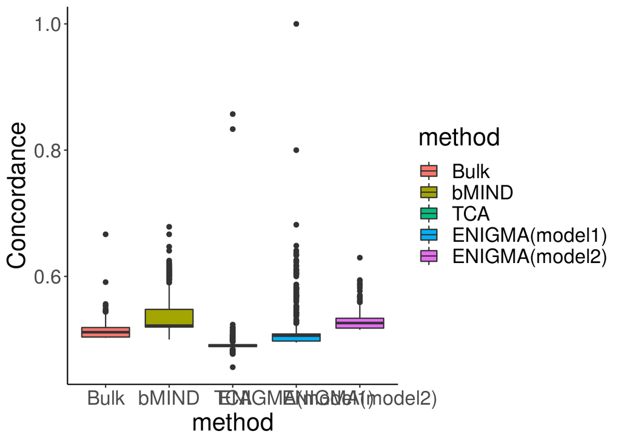

```r
gene <- intersect(rownames(DEG_list_pancreas_hba1c_bulk),rownames(DEG_list_pancreas_sc_true))
prob_bulk <- evaluate_concordance_pancreas(DEG_list_pancreas_hba1c_bulk[gene,],DEG_list_pancreas_sc_true[gene,])
gene <- intersect(rownames(DEG_list_pancreas_hba1c_tca),rownames(DEG_list_pancreas_sc_true))
prob_tca <- evaluate_concordance_pancreas(DEG_list_pancreas_hba1c_tca[gene,],DEG_list_pancreas_sc_true[gene,])
gene <- intersect(rownames(DEG_list_pancreas_hba1c_bmind),rownames(DEG_list_pancreas_sc_true))
prob_bmind <- evaluate_concordance_pancreas(DEG_list_pancreas_hba1c_bmind[gene,],DEG_list_pancreas_sc_true[gene,])
gene <- intersect(rownames(DEG_list_pancreas_hba1c_model1),rownames(DEG_list_pancreas_sc_true))
prob_l2max_model1 <- evaluate_concordance_pancreas(DEG_list_pancreas_hba1c_model1[gene,],DEG_list_pancreas_sc_true[gene,])
gene <- intersect(rownames(DEG_list_pancreas_hba1c_model2),rownames(DEG_list_pancreas_sc_true))
prob_l2max_model2 <- evaluate_concordance_pancreas(DEG_list_pancreas_hba1c_model2[gene,],DEG_list_pancreas_sc_true[gene,])
beta_cell_performance <- c(prob_bulk,prob_tca,prob_bmind,prob_l2max_model1,prob_l2max_model2)
model <- c(rep("Bulk",length(prob_bulk)),rep("TCA",length(prob_tca)),rep("bMIND",length(prob_bmind)),rep("ENIGMA(model1)",length(prob_l2max_model1)),rep("ENIGMA(model2)",length(prob_l2max_model2)))
concordance_res = data.frame(concordance = beta_cell_performance,model = model, cell_type = rep("Beta cell",length(model)))
colnames(concordance_res) = c("concordance","method","CellType")

concordance_res$method <- as.factor(concordance_res$method)
concordance_res$method <- factor(concordance_res$method,levels = c("Bulk","bMIND","TCA","ENIGMA(model1)","ENIGMA(model2)"))
concordance_res <- concordance_res[is.nan(concordance_res$concordance)==FALSE,]
p1 <- ggplot(concordance_res, aes(x=method, y=concordance,fill = method)) +
  geom_boxplot()+labs(y="Concordance")+
  theme_classic() +
  theme(strip.background = element_blank(),strip.text.x = element_blank(),text = element_text(size=20))
p1
```

perform benchmark through evaluating the concordance on top500 most significant DEGs for each methods

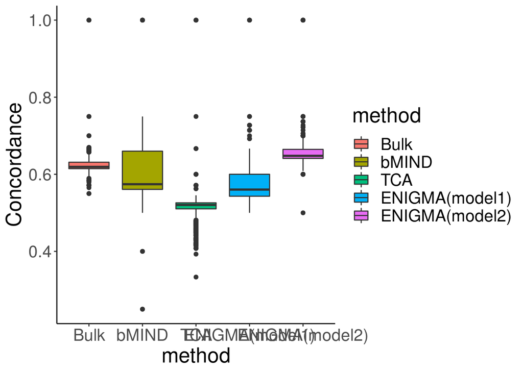

```r
gene <- intersect(rownames(DEG_list_pancreas_hba1c_bulk),rownames(DEG_list_pancreas_sc_true))
prob_bulk <- evaluate_concordance_pancreas_top500(DEG_list_pancreas_hba1c_bulk[gene,],DEG_list_pancreas_sc_true[gene,])
gene <- intersect(rownames(DEG_list_pancreas_hba1c_tca),rownames(DEG_list_pancreas_sc_true))
prob_tca <- evaluate_concordance_pancreas_top500(DEG_list_pancreas_hba1c_tca[gene,],DEG_list_pancreas_sc_true[gene,])
gene <- intersect(rownames(DEG_list_pancreas_hba1c_bmind),rownames(DEG_list_pancreas_sc_true))
prob_bmind <- evaluate_concordance_pancreas_top500(DEG_list_pancreas_hba1c_bmind[gene,],DEG_list_pancreas_sc_true[gene,])
gene <- intersect(rownames(DEG_list_pancreas_hba1c_model1),rownames(DEG_list_pancreas_sc_true))
prob_l2max_model1 <- evaluate_concordance_pancreas_top500(DEG_list_pancreas_hba1c_model1[gene,],DEG_list_pancreas_sc_true[gene,])
gene <- intersect(rownames(DEG_list_pancreas_hba1c_model2),rownames(DEG_list_pancreas_sc_true))
prob_l2max_model2 <- evaluate_concordance_pancreas_top500(DEG_list_pancreas_hba1c_model2[gene,],DEG_list_pancreas_sc_true[gene,])
beta_cell_performance <- c(prob_bulk,prob_tca,prob_bmind,prob_l2max_model1,prob_l2max_model2)
model <- c(rep("Bulk",length(prob_bulk)),rep("TCA",length(prob_tca)),rep("bMIND",length(prob_bmind)),rep("ENIGMA(model1)",length(prob_l2max_model1)),rep("ENIGMA(model2)",length(prob_l2max_model2)))
concordance_res = data.frame(concordance = beta_cell_performance,model = model, cell_type = rep("Beta cell",length(model)))
colnames(concordance_res) = c("concordance","method","CellType")

concordance_res$method <- as.factor(concordance_res$method)
concordance_res$method <- factor(concordance_res$method,levels = c("Bulk","bMIND","TCA","ENIGMA(model1)","ENIGMA(model2)"))
concordance_res <- concordance_res[is.nan(concordance_res$concordance)==FALSE,]
p1 <- ggplot(concordance_res, aes(x=method, y=concordance,fill = method)) +
  geom_boxplot()+labs(y="Concordance")+
  theme_classic() +
  theme(strip.background = element_blank(),strip.text.x = element_blank(),text = element_text(size=20))
p1
```

Through the boxplot, we could conclude that the performance of ENIGMA(model2) could better identify the T2D-associate gene expression variation in beta cell, therefore, we used ENIGMA(model2) to construct the beta cell specific network

## Construct Beta cell type-specific gene co-expression network

repeat the same analysis to construct the network in beta cell

```r
betaCell <- egm_model2$X_k[,,3]
featureGene <- apply(betaCell,1,var)
betaCell <- betaCell[order(featureGene,decreasing=TRUE)[1:8000],]

##Construct WGCNA network and compare with bulk-expression based network
powers = c(c(1:10), seq(from = 12, to=30, by=2))
sft = pickSoftThreshold(t(betaCell), powerVector = powers, verbose = 5,networkType="signed")
```

```
## pickSoftThreshold: will use block size 5592.
##  pickSoftThreshold: calculating connectivity for given powers...
##    ..working on genes 1 through 5592 of 8000
```

```
##    ..working on genes 5593 through 8000 of 8000
##    Power SFT.R.sq   slope truncated.R.sq mean.k. median.k. max.k.
## 1      1 0.015500  3.8600          0.840 4020.00   4020.00 4240.0
## 2      2 0.125000 -6.0700          0.883 2250.00   2250.00 2590.0
## 3      3 0.043000 -1.7400          0.899 1360.00   1370.00 1750.0
## 4      4 0.012800 -0.5570          0.859  878.00    886.00 1250.0
## 5      5 0.000423  0.0598          0.892  594.00    597.00  929.0
## 6      6 0.019000 -0.3220          0.901  418.00    416.00  738.0
## 7      7 0.115000 -0.7190          0.918  303.00    299.00  609.0
## 8      8 0.232000 -0.9660          0.935  225.00    219.00  512.0
## 9      9 0.342000 -1.1200          0.955  171.00    163.00  437.0
## 10    10 0.441000 -1.2500          0.964  132.00    123.00  378.0
## 11    12 0.615000 -1.4800          0.976   83.00     73.20  290.0
## 12    14 0.715000 -1.6500          0.969   54.70     45.20  229.0
## 13    16 0.799000 -1.7200          0.977   37.50     29.00  185.0
## 14    18 0.854000 -1.7500          0.985   26.60     19.10  152.0
## 15    20 0.880000 -1.7800          0.983   19.40     12.80  127.0
## 16    22 0.892000 -1.8100          0.976   14.40      8.85  107.0
## 17    24 0.901000 -1.8200          0.973   11.00      6.21   91.9
## 18    26 0.912000 -1.8200          0.976    8.50      4.42   79.3
## 19    28 0.911000 -1.8100          0.970    6.68      3.19   68.9
## 20    30 0.920000 -1.7800          0.972    5.32      2.33   60.2
```

```r
softPower = 24;
adjacency = adjacency(t(betaCell), power = softPower,type="signed");
TOM = TOMsimilarity(adjacency);
```

```
## ..connectivity..
## ..matrix multiplication (system BLAS)..
## ..normalization..
## ..done.
```

```r
dissTOM = 1-TOM

geneTree = hclust(as.dist(dissTOM), method = "average");
# Plot the resulting clustering tree (dendrogram)
sizeGrWindow(12,9)
plot(geneTree, xlab="", sub="", main = "Gene clustering on TOM-based dissimilarity",
labels = FALSE, hang = 0.04);
minModuleSize = 30;
# Module identification using dynamic tree cut:
dynamicMods = cutreeDynamic(dendro = geneTree, distM = dissTOM,
deepSplit = 2, pamRespectsDendro = FALSE,
minClusterSize = minModuleSize);
```

```
##  ..cutHeight not given, setting it to 0.998  ===>  99% of the (truncated) height range in dendro.
##  ..done.
```

```r
dynamicColors = labels2colors(dynamicMods)
table(dynamicColors)
```

```
## dynamicColors
##         bisque4           black            blue           brown          brown4
##              71             247             373             323              72
##            cyan       darkgreen        darkgrey     darkmagenta  darkolivegreen
##             183             140             135              95              96
##      darkorange     darkorange2         darkred   darkslateblue   darkturquoise
##             123              75             144              70             138
##     floralwhite           green     greenyellow            grey          grey60
##              76             274             202             179             162
##           ivory       lightcyan      lightcyan1      lightgreen      lightpink4
##              77             175              77             161              43
## lightsteelblue1     lightyellow         magenta          maroon   mediumpurple3
##              82             154             209              47              86
##    midnightblue    navajowhite2          orange      orangered4   paleturquoise
##             180              49             126              87             105
##  palevioletred3            pink           plum1           plum2          purple
##              49             217              88              67             207
##             red       royalblue     saddlebrown          salmon         salmon4
##             249             147             116             195              49
##         sienna3         skyblue        skyblue3       steelblue             tan
##              92             116              88             111             201
##        thistle1        thistle2       turquoise          violet           white
##              52              67             428             102             117
##          yellow     yellowgreen
##             318              88
```

```r
# Plot the dendrogram and colors underneath
sizeGrWindow(8,6)
plotDendroAndColors(geneTree, dynamicColors, "Dynamic Tree Cut",
dendroLabels = FALSE, hang = 0.03,
addGuide = TRUE, guideHang = 0.05,
main = "Gene dendrogram and module colors")

MEList = moduleEigengenes(t(betaCell), colors = dynamicColors)
MEs = MEList$eigengenes
# Calculate dissimilarity of module eigengenes
MEDiss = 1-cor(MEs);
# Cluster module eigengenes
METree = hclust(as.dist(MEDiss), method = "average");

MEDissThres = 0.25
# Plot the cut line into the dendrogram
abline(h=MEDissThres, col = "red")
# Call an automatic merging function
merge = mergeCloseModules(t(betaCell), dynamicColors, cutHeight = MEDissThres, verbose = 3)
```

```
##  mergeCloseModules: Merging modules whose distance is less than 0.25
##    multiSetMEs: Calculating module MEs.
##      Working on set 1 ...
##      moduleEigengenes: Calculating 57 module eigengenes in given set.
##    multiSetMEs: Calculating module MEs.
##      Working on set 1 ...
##      moduleEigengenes: Calculating 35 module eigengenes in given set.
##    multiSetMEs: Calculating module MEs.
##      Working on set 1 ...
##      moduleEigengenes: Calculating 29 module eigengenes in given set.
##    multiSetMEs: Calculating module MEs.
##      Working on set 1 ...
##      moduleEigengenes: Calculating 27 module eigengenes in given set.
##    Calculating new MEs...
##    multiSetMEs: Calculating module MEs.
##      Working on set 1 ...
##      moduleEigengenes: Calculating 27 module eigengenes in given set.
```

```r
# The merged module colors
mergedColors = merge$colors;
# Eigengenes of the new merged modules:
mergedMEs = merge$newMEs;

sizeGrWindow(12, 9)
#pdf(file = "Plots/geneDendro-3.pdf", wi = 9, he = 6)
plotDendroAndColors(geneTree, cbind(dynamicColors, mergedColors),
c("Dynamic Tree Cut", "Merged dynamic"),
dendroLabels = FALSE, hang = 0.03,
addGuide = TRUE, guideHang = 0.05)
```

Repeat the analysis in bulk RNA-seq

```r
bulk <- log2(tmp_pancreas$bulk[rownames(betaCell),]+1)

powers = c(c(1:10), seq(from = 12, to=30, by=2))
sft = pickSoftThreshold(t(bulk), powerVector = powers, verbose = 5,networkType="signed")
```

```
## pickSoftThreshold: will use block size 5592.
##  pickSoftThreshold: calculating connectivity for given powers...
##    ..working on genes 1 through 5592 of 8000
##    ..working on genes 5593 through 8000 of 8000
##    Power SFT.R.sq  slope truncated.R.sq mean.k. median.k. max.k.
## 1      1 0.041800  9.500          0.968 4030.00   4030.00   4230
## 2      2 0.012000  1.630          0.898 2240.00   2240.00   2500
## 3      3 0.000295  0.104          0.975 1340.00   1340.00   1710
## 4      4 0.045900 -0.796          0.974  856.00    846.00   1290
## 5      5 0.176000 -1.110          0.960  574.00    559.00   1030
## 6      6 0.329000 -1.240          0.938  401.00    382.00    847
## 7      7 0.454000 -1.270          0.913  289.00    268.00    714
## 8      8 0.573000 -1.320          0.900  215.00    193.00    613
## 9      9 0.686000 -1.380          0.895  163.00    142.00    533
## 10    10 0.778000 -1.470          0.906  127.00    106.00    469
## 11    12 0.868000 -1.570          0.918   80.30     61.20    376
## 12    14 0.921000 -1.610          0.931   53.70     36.90    308
## 13    16 0.952000 -1.610          0.952   37.50     23.20    257
## 14    18 0.964000 -1.590          0.958   27.20     15.00    219
## 15    20 0.966000 -1.580          0.960   20.30      9.91    190
## 16    22 0.970000 -1.550          0.964   15.50      6.72    166
## 17    24 0.969000 -1.520          0.963   12.10      4.64    147
## 18    26 0.968000 -1.490          0.961    9.62      3.26    130
## 19    28 0.972000 -1.460          0.967    7.77      2.33    117
## 20    30 0.970000 -1.440          0.966    6.37      1.68    106
```

```r
softPower = 14;
adjacency_bulk = adjacency(t(bulk), power = softPower,type="signed");
TOM_bulk = TOMsimilarity(adjacency_bulk);
```

```
## ..connectivity..
## ..matrix multiplication (system BLAS)..
## ..normalization..
## ..done.
```

```r
dissTOM_bulk = 1-TOM_bulk

geneTree_bulk = hclust(as.dist(dissTOM_bulk), method = "average");
# Plot the resulting clustering tree (dendrogram)
sizeGrWindow(12,9)
plot(geneTree_bulk, xlab="", sub="", main = "Gene clustering on TOM-based dissimilarity",
labels = FALSE, hang = 0.04);
minModuleSize = 30;
# Module identification using dynamic tree cut:
dynamicMods_bulk = cutreeDynamic(dendro = geneTree_bulk, distM = dissTOM_bulk,
deepSplit = 2, pamRespectsDendro = FALSE,
minClusterSize = minModuleSize);
```

```
##  ..cutHeight not given, setting it to 0.995  ===>  99% of the (truncated) height range in dendro.
##  ..done.
```

```r
dynamicColors_bulk = labels2colors(dynamicMods_bulk)
table(dynamicColors_bulk)
```

```
## dynamicColors_bulk
##         bisque4           black            blue           brown          brown4
##              35             301             537             422              50
##            cyan       darkgreen        darkgrey     darkmagenta  darkolivegreen
##             208             140             127              86              87
##      darkorange     darkorange2         darkred   darkturquoise     floralwhite
##             120              51             143             137              52
##           green     greenyellow          grey60           ivory       lightcyan
##             366             213             178              62             189
##      lightcyan1      lightgreen lightsteelblue1     lightyellow         magenta
##              64             168              71             166             246
##   mediumpurple3    midnightblue          orange      orangered4   paleturquoise
##              75             207             126              76              89
##            pink           plum1          purple             red       royalblue
##             248              77             226             343             158
##     saddlebrown          salmon         sienna3         skyblue        skyblue3
##              95             210              86              98              80
##       steelblue             tan       turquoise          violet           white
##              93             211             619              87             101
##          yellow     yellowgreen
##             393              83
```

```r
# Plot the dendrogram and colors underneath
sizeGrWindow(8,6)
plotDendroAndColors(geneTree_bulk, cbind(dynamicColors_bulk),
c("Acinar Expression Module"),
dendroLabels = FALSE, hang = 0.03,
addGuide = TRUE, guideHang = 0.05)


MEList_bulk = moduleEigengenes(t(bulk), colors = dynamicColors_bulk)
MEs_bulk = MEList_bulk$eigengenes
# Calculate dissimilarity of module eigengenes
MEDiss_bulk = 1-cor(MEs_bulk);
# Cluster module eigengenes
METree_bulk = hclust(as.dist(MEDiss_bulk), method = "average");

MEDissThres_bulk = 0.25
# Plot the cut line into the dendrogram
abline(h=MEDissThres_bulk, col = "red")
# Call an automatic merging function
merge_bulk = mergeCloseModules(t(bulk), dynamicColors_bulk, cutHeight = MEDissThres_bulk, verbose = 3)
```

```
##  mergeCloseModules: Merging modules whose distance is less than 0.25
##    multiSetMEs: Calculating module MEs.
##      Working on set 1 ...
##      moduleEigengenes: Calculating 47 module eigengenes in given set.
##    multiSetMEs: Calculating module MEs.
##      Working on set 1 ...
##      moduleEigengenes: Calculating 34 module eigengenes in given set.
##    multiSetMEs: Calculating module MEs.
##      Working on set 1 ...
##      moduleEigengenes: Calculating 29 module eigengenes in given set.
##    multiSetMEs: Calculating module MEs.
##      Working on set 1 ...
##      moduleEigengenes: Calculating 27 module eigengenes in given set.
##    Calculating new MEs...
##    multiSetMEs: Calculating module MEs.
##      Working on set 1 ...
##      moduleEigengenes: Calculating 27 module eigengenes in given set.
```

```r
# The merged module colors
mergedColors_bulk = merge_bulk$colors;
# Eigengenes of the new merged modules:
mergedMEs_bulk = merge_bulk$newMEs;
```

Joint plot the beta cell co-expression module and bulk gene co-expression modules

```r
sizeGrWindow(12, 9)
#pdf(file = "Plots/geneDendro-3.pdf", wi = 9, he = 6)
plotDendroAndColors(geneTree, cbind(mergedColors,mergedColors_bulk),
c("Dynamic Tree Cut", "Merged dynamic"),
dendroLabels = FALSE, hang = 0.03,
addGuide = TRUE, guideHang = 0.05)
```

## Identify phenotype (BMI and HbA1c) related modules

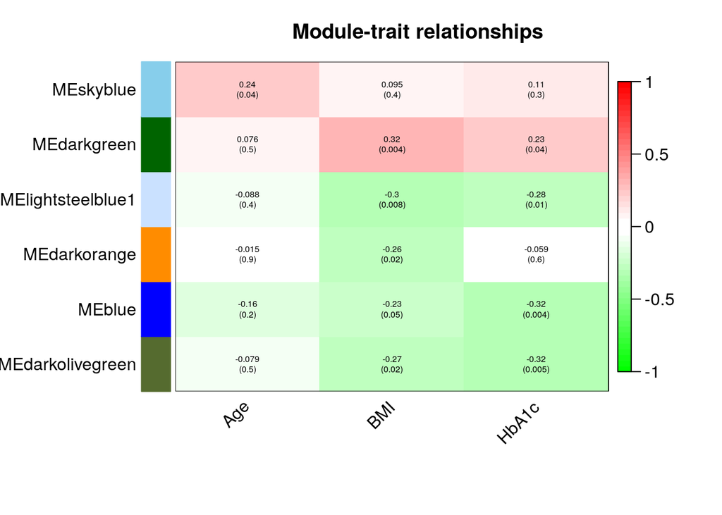

```r
MEs = orderMEs(mergedMEs)
moduleTraitCor = cor(MEs[sample,], metadata, use = "p");
moduleTraitPvalue = corPvalueStudent(moduleTraitCor, length(sample));
select.row <- apply(moduleTraitPvalue,1,function(x) sum(x<0.05)>0)
moduleTraitCor <- moduleTraitCor[select.row,]
moduleTraitPvalue <- moduleTraitPvalue[select.row,]

textMatrix = paste(signif(moduleTraitCor, 2), "\n(",
signif(moduleTraitPvalue, 1), ")", sep = "");
dim(textMatrix) = dim(moduleTraitCor)
par(mar = c(6, 8.5, 3, 3));
# Display the correlation values within a heatmap plot
labeledHeatmap(Matrix = moduleTraitCor,
xLabels = colnames(metadata),
yLabels = names(MEs)[select.row],
ySymbols = names(MEs)[select.row],
colorLabels = FALSE,
colors = greenWhiteRed(50),
textMatrix = textMatrix,
setStdMargins = FALSE,
cex.text = 0.5,
zlim = c(-1,1),
main = paste("Module-trait relationships"))
```

perform the GO enrichment analysis to the interesting modules (darkgreen and blue)

```r
darkgreen_gene <- rownames(betaCell)[mergedColors=="darkgreen"]
darkgreen_gene <- bitr(darkgreen_gene,fromType="SYMBOL",toType="ENTREZID",org.Hs.eg.db)
goterm_darkgreen <- enrichGO(darkgreen_gene[,2], ont="BP",pvalueCutoff = 0.05,qvalueCutoff = 0.05,OrgDb = org.Hs.eg.db,readable=TRUE)

df_barMarker2 <- data.frame(pval = -log10(summary(goterm_darkgreen)[1:4,]$p.adjust),goterm=summary(goterm_darkgreen)[1:4,]$Description)
df_barMarker2$goterm_name <- factor(c(summary(goterm_darkgreen)[1:4,]$Description),levels=c(c(summary(goterm_darkgreen)[1:4,]$Description)[order(-log10(summary(goterm_darkgreen)[1:4,]$p.adjust),decreasing=FALSE)]))
```

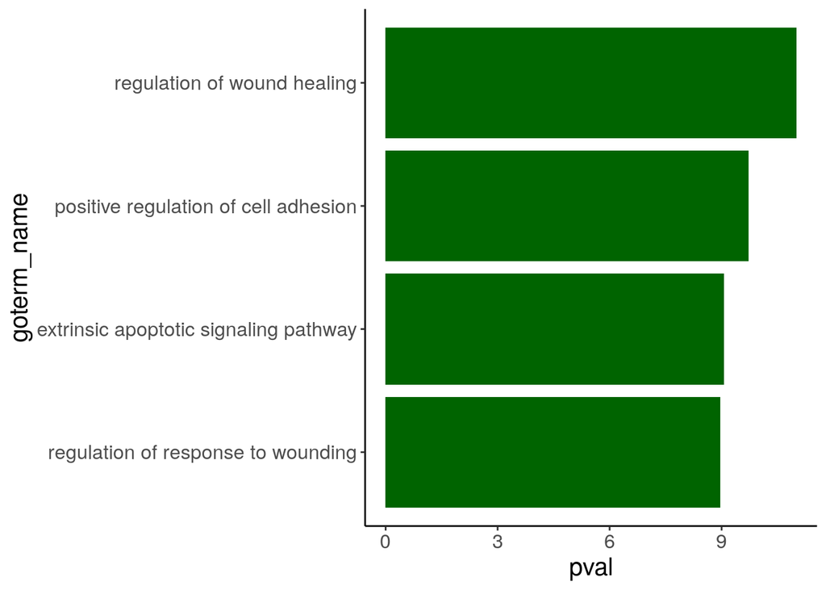

```r
p_darkgreen_go <-ggplot(data=df_barMarker2, aes(x=goterm_name, y=pval)) +
    geom_bar(stat="identity",fill="dark green")+coord_flip()+theme_classic()+theme(text = element_text(size=15))
p_darkgreen_go
```

```r
blue_gene <- rownames(betaCell)[mergedColors=="blue"]
blue_gene <- bitr(blue_gene,fromType="SYMBOL",toType="ENTREZID",org.Hs.eg.db)
goterm_blue <- enrichGO(blue_gene[,2], ont="BP",pvalueCutoff = 0.05,qvalueCutoff = 0.05,OrgDb = org.Hs.eg.db,readable=TRUE)

df_barMarker2 <- data.frame(pval = -log10(summary(goterm_blue)[1:4,]$p.adjust),goterm=summary(goterm_blue)[1:4,]$Description)
df_barMarker2$goterm_name <- factor(c(summary(goterm_blue)[1:4,]$Description),levels=c(c(summary(goterm_blue)[1:4,]$Description)[order(-log10(summary(goterm_blue)[1:4,]$p.adjust),decreasing=FALSE)]))
```

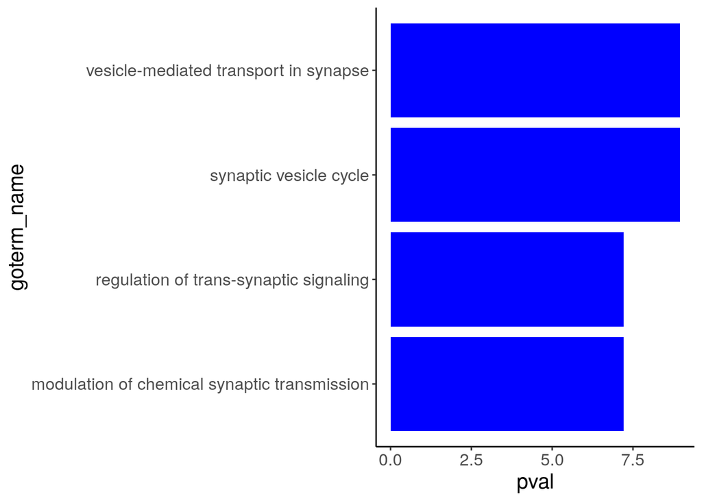

```r
p_blue_go <-ggplot(data=df_barMarker2, aes(x=goterm_name, y=pval)) +
    geom_bar(stat="identity",fill="blue")+coord_flip()+theme_classic()+theme(text = element_text(size=15))
p_blue_go
```

## Calculate enrichment of darkgreen module with cellular senescence genes

```r
library(VennDiagram)
```

```r
darkgreen_gene <- rownames(betaCell)[mergedColors=="darkgreen"]
venn.plot <- venn.diagram(
    list(darkgreen=darkgreen_gene,
         CellAge=intersect(CellAge$gene_symbol,rownames(betaCell))),
    "venn_plot.tiff"
)
CAG = rep(0,length(rownames(betaCell)));CAG[rownames(betaCell) %in% intersect(CellAge$gene_symbol,rownames(betaCell))] <- 1
DKG = rep(0,length(rownames(betaCell)));DKG[rownames(betaCell) %in% darkgreen_gene] <- 1
fisher.test(table(CAG,DKG),alternative="greater")
```

```
##
##  Fisher's Exact Test for Count Data
##
## data:  table(CAG, DKG)
## p-value = 0.001373
## alternative hypothesis: true odds ratio is greater than 1
## 95 percent confidence interval:
##  1.168898      Inf
## sample estimates:
## odds ratio
##   1.412291
```

## Compare gene significance difference from beta to bulk

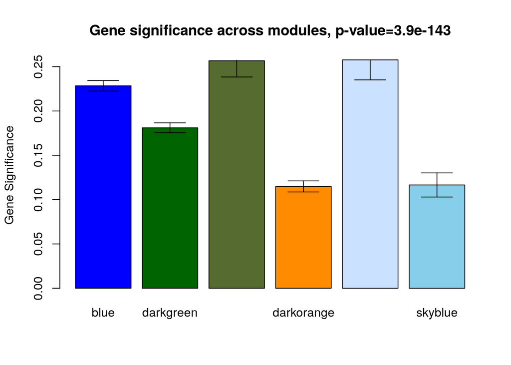

```r
GS1=as.numeric(cor(metadata$HbA1c,t(betaCell[,sample]), method="sp"))
GeneSignificance=abs(GS1)
GeneSignificance <- GeneSignificance[mergedColors %in% gsub("ME","",rownames(moduleTraitCor))]
colorh1 <- mergedColors[mergedColors %in% gsub("ME","",rownames(moduleTraitCor))]
plotModuleSignificance(GeneSignificance,colorh1)
```

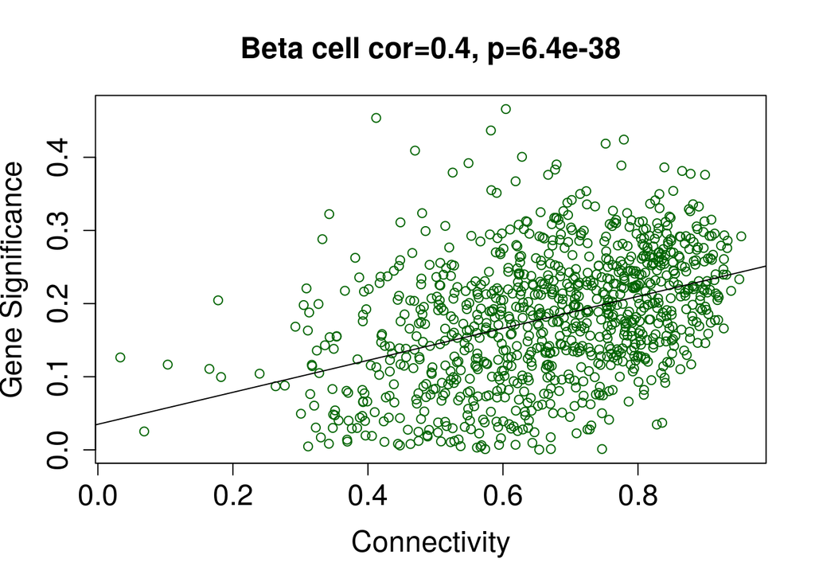

```r
Connectivity_beta <- WGCNA::intramodularConnectivity(adjacency,mergedColors)
Connectivity_beta$module <- mergedColors
##Visualize darkgreen module network
Connectivity_beta_darkgreen <- subset(Connectivity_beta, module %in% "darkgreen")
##calculate module membership
mm <- cor(t(betaCell[rownames(Connectivity_beta_darkgreen),]),MEs[,"MEdarkgreen"])
Connectivity_beta_darkgreen$MM <- mm
Connectivity_beta_darkgreen <- Connectivity_beta_darkgreen[order(Connectivity_beta_darkgreen$MM, decreasing=TRUE),]

MEList_betaCell_beta = moduleEigengenes(t(betaCell), colors = mergedColors)$eigengenes
cor_mm <- abs(cor(MEList_betaCell_beta[,"MEdarkgreen"],t(betaCell[rownames(Connectivity_beta_darkgreen),]),method="sp"))
GS1=abs(as.numeric(cor(metadata$HbA1c,t(betaCell[rownames(Connectivity_beta_darkgreen),sample]), method="sp")))

verboseScatterplot(cor_mm,
GS1, col="darkgreen",
main="Beta cell",
xlab = "Connectivity", ylab = "Gene Significance", abline = TRUE)
```

## Show the senescence module is specific activate in beta cell

```r
pancreas <- cell_type_pancreas <- NULL
for(i in 1:ncol(tmp_pancreas$cell_type1)){
 pancreas <- cbind(pancreas,egm_model2$X_k[,Fra_pancreas$theta[,i]!= -1,i])
 cell_type_pancreas <- c(cell_type_pancreas,rep(colnames(tmp_pancreas$cell_type1)[i],sum(Fra_pancreas$theta[,i]!= -1)))
}
darkgreen_gene <- rownames(betaCell)[mergedColors=="darkgreen"]
colnames(pancreas) <- paste0("Sample-",1:ncol(pancreas))

pancreas_ranking <- AUCell::AUCell_buildRankings(cbind(pancreas,log2(tmp_pancreas$bulk+1)))
```

```
## Quantiles for the number of genes detected by cell:
## (Non-detected genes are shuffled at the end of the ranking. Keep it in mind when choosing the threshold for calculating the AUC).
```

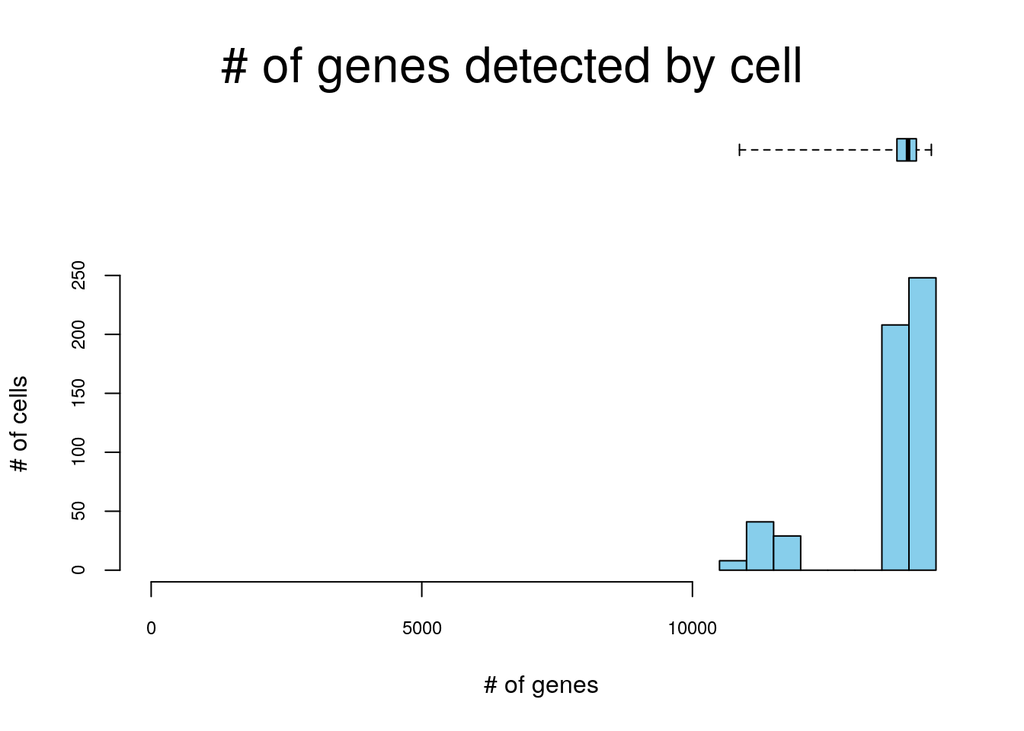

```
##      min       1%       5%      10%      50%     100%
## 10869.00 10956.32 11060.65 11505.00 13983.50 14414.00
```

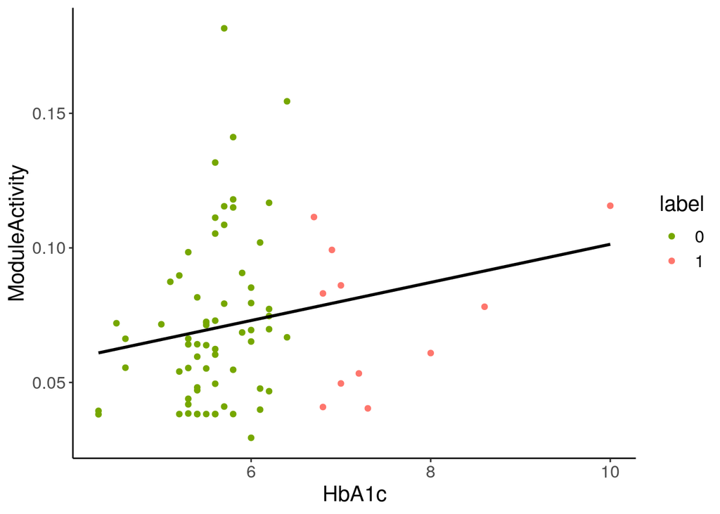

```r
auc <- AUCell::AUCell_calcAUC(list(darkgreen = darkgreen_gene),pancreas_ranking)
auc <- AUCell::getAUC(auc)

bulk_darkgreen <- auc[1,colnames(tmp_pancreas$bulk)]
beta_darkgreen <- auc[1,colnames(pancreas)[cell_type_pancreas %in% "beta"]]
names(bulk_darkgreen) <- names(beta_darkgreen) <- colnames(tmp_pancreas$bulk)


color <- label[Fra_pancreas$theta[sample,3]!=1]
color[label[Fra_pancreas$theta[sample,3]!=1]==1] <- rgb(254,118,109,maxColorValue = 255)
color[label[Fra_pancreas$theta[sample,3]!=1]==0] <- rgb(118,167,0,maxColorValue = 255)
scatter_dat <- data.frame(HbA1c=metadata$HbA1c[Fra_pancreas$theta[sample,3]!=1],ModuleActivity=beta_darkgreen[sample][Fra_pancreas$theta[sample,3]!=1],label=label[Fra_pancreas$theta[sample,3]!=1],color=color)
scatter_dat$label <- as.factor(scatter_dat$label)

p_ModuleActivity <- ggplot(scatter_dat, aes(x=HbA1c, y=ModuleActivity, color=label)) + scale_color_manual(values=c(rgb(118,167,0,maxColorValue = 255),rgb(254,118,109,maxColorValue = 255)))+
    geom_point()+theme_classic()+theme(text = element_text(size=15))+geom_smooth(method=lm, se=FALSE, fullrange=TRUE,col="black")
p_ModuleActivity
```

```r
cor.test(scatter_dat$HbA1c, scatter_dat$ModuleActivity,method="sp")
```

```
##
##  Spearman's rank correlation rho
##
## data:  scatter_dat$HbA1c and scatter_dat$ModuleActivity
## S = 55851, p-value = 0.01944
## alternative hypothesis: true rho is not equal to 0
## sample estimates:
##       rho
## 0.2658574
```

plot the hub gene co-expression network for darkgreen modules

```r
color1=mergedColors;names(color1) <- rownames(betaCell)
restGenes= rownames(Connectivity_beta_darkgreen)[1:10]
diss1=1-TOMsimilarityFromExpr( t(betaCell)[, restGenes], power = 24 )
```

```
## TOM calculation: adjacency..
## ..will not use multithreading.
##  Fraction of slow calculations: 0.000000
## ..connectivity..
## ..matrix multiplication (system BLAS)..
## ..normalization..
## ..done.
```

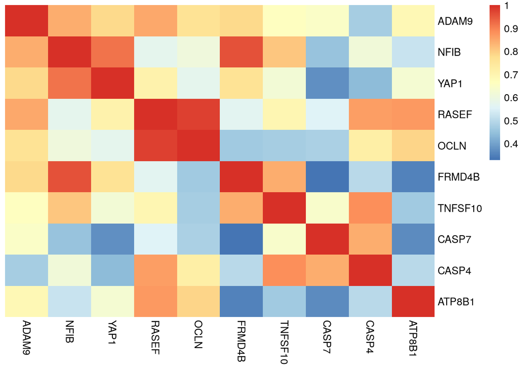

```r
M <- 1-diss1^24
rownames(M) <- colnames(M) <- restGenes
pheatmap(M[rownames(Connectivity_beta_darkgreen)[1:10],rownames(Connectivity_beta_darkgreen)[1:10]],cluster_cols=FALSE,cluster_rows=FALSE,border=FALSE)
```